# Clustering

## Introdução

Para este problema temos os dados das emendas parlamentares e como os deputados usaram dessas emendas para conseguir verbas para diversas áreas. De acordo com a Constituição, a emenda parlamentar é o instrumento que o Congresso Nacional possui para participar da elaboração do orçamento anual. Por meio das emendas os parlamentares procuram aperfeiçoar a proposta encaminhada pelo Poder Executivo, visando uma melhor alocação dos recursos públicos.

## O agrupamento

Após o agrupamento tivemos 3 grupos bem divididos, um com deputados com emendas de pouco valor em Assistencia Social e Segurança Publica, outro grupo com altas emendas de Assistência Social e outro com altas emendas de Segurança Pública.

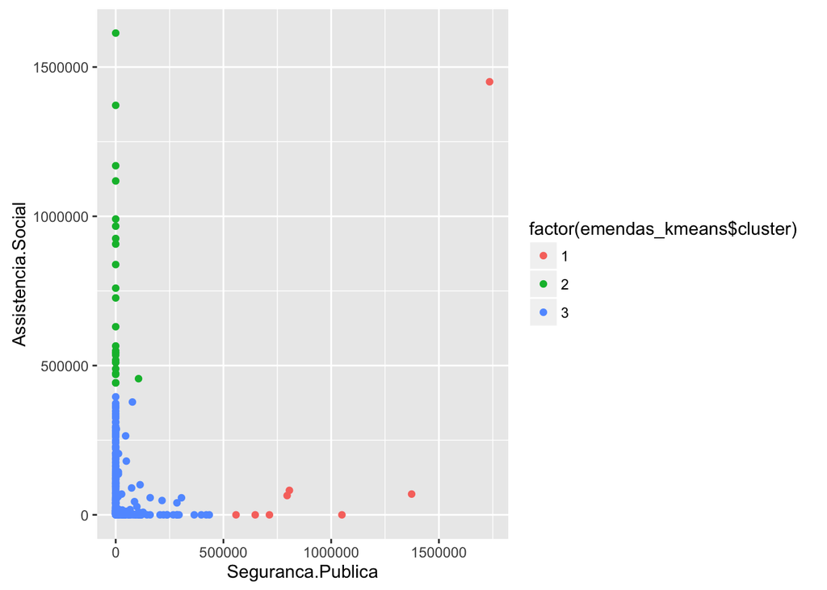

```r
library(plotly)
library(dplyr)
library(ggplot2)
library(gapminder)
emendas <- read.csv("emendas_area_parlamentar.csv")
emendas.c = subset(emendas, Assistencia.Social > 0 | Seguranca.Publica > 0)
emendas_kmeans <- emendas.c %>%
  select(Seguranca.Publica, Assistencia.Social) %>%
  kmeans(centers = 3, nstart = 100, iter.max = 50)

ggplot(emendas.c, aes(x = Seguranca.Publica, y = Assistencia.Social))+
  geom_point(aes(color = factor(emendas_kmeans$cluster)))
```

Após observar o gráfico podemos observar que há esses 3 grupos, e que deputados que criam muitas emendas para Segurança Pública tendem a criar menos para Assistência Social e vice-versa.